# DataSci - Regression Models

Multivariable Regression

Anya Chaliotis

June 30, 2016

## Swiss Fertility and Socioeconomic Indicators Data

This work is a replication of an examaple from a Coursera course offered by Johns Hopkins University, Data Science, Regression Models. See citations section for source of code and learning concepts.

“Switzerland, in 1888, was entering a period known as the demographic transition; i.e., its fertility was beginning to fall from the high level typical of underdeveloped countries. Given the data, we are looking into what explains fertility in this province” (R Core Team, 2015).

### Dataset

“Standardized fertility measure and socio-economic indicators for each of 47 French-speaking provinces of Switzerland at about 1888” (R Core Team, 2015). A data frame with 47 observations on 6 variables, each of which is in percent.  
- Fertility Ig, ‘common standardized fertility measure’  
- Agriculture % of males involved in agriculture as occupation  
- Examination % draftees receiving highest mark on army examination  
- Education % education beyond primary school for draftees.  
- Catholic % ‘catholic’ (as opposed to ‘protestant’).  
- Infant.Mortality live births who live less than 1 year.  
All variables but ‘Fertility’ give proportions of the population.

### EDA (Exploratory Data Analysis)

```
##    Fertility      Agriculture     Examination      Education
##  Min.   :35.00   Min.   : 1.20   Min.   : 3.00   Min.   : 1.00
##  1st Qu.:64.70   1st Qu.:35.90   1st Qu.:12.00   1st Qu.: 6.00
##  Median :70.40   Median :54.10   Median :16.00   Median : 8.00
##  Mean   :70.14   Mean   :50.66   Mean   :16.49   Mean   :10.98
##  3rd Qu.:78.45   3rd Qu.:67.65   3rd Qu.:22.00   3rd Qu.:12.00
##  Max.   :92.50   Max.   :89.70   Max.   :37.00   Max.   :53.00
##     Catholic       Infant.Mortality
##  Min.   :  2.150   Min.   :10.80
##  1st Qu.:  5.195   1st Qu.:18.15
##  Median : 15.140   Median :20.00
##  Mean   : 41.144   Mean   :19.94
##  3rd Qu.: 93.125   3rd Qu.:21.70
##  Max.   :100.000   Max.   :26.60
```

#### Marginal Plots with Correlation

The marginal relationship of interest without considering the other variables.

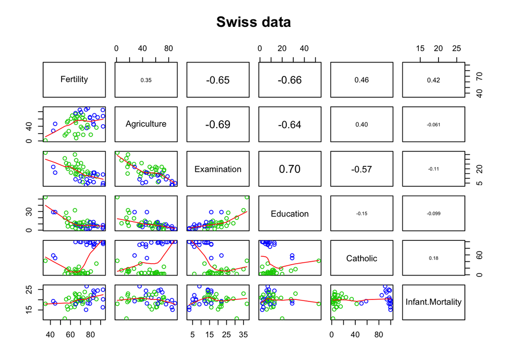

### Regression Models

#### Model #1 - fit all the variables

Look at all the variables as the predictors

```r
### Calling lm()
fit_all <- lm(Fertility ~ . , data = swiss)
summary(fit_all)$coefficients
```

```
##                    Estimate  Std. Error   t value     Pr(>|t|)
## (Intercept)      66.9151817 10.70603759  6.250229 1.906051e-07
## Agriculture      -0.1721140  0.07030392 -2.448142 1.872715e-02
## Examination      -0.2580082  0.25387820 -1.016268 3.154617e-01
## Education        -0.8709401  0.18302860 -4.758492 2.430605e-05
## Catholic          0.1041153  0.03525785  2.952969 5.190079e-03
## Infant.Mortality  1.0770481  0.38171965  2.821568 7.335715e-03
```

Interpreation example: Agriculture  
- We estimate an expected 0.17 decrease in standardized fertility for every 1% increase in percentage of males involved in agriculture in holding the remaining variables constant.  
- Std. Error = 0.07, indicates how precise the variable is, or statistical variability of the coefficient  
- t-statistic = -2.448, it’s the estimate divided by the std error (-0.17 divided by 0.07). R conveniently gives it to us.  
- P-value = 0.01873, it’s the probability of getting a t-statistic as extreme as that. As small as negative 2.448 or smaller, and we double that p-value because of a two-sided test.  
- The t-test for $H_0: \beta_{Agri} = 0$ versus $H_a: \beta_{Agri} \neq 0$ is significant.

Now, we go through other models and look at how the process of model selection changes our estimates.

#### Model #2 - only Agriculture as a predictor

Look at the association between fertility and agriculture.

```r
summary(lm(Fertility ~ Agriculture, data = swiss))$coefficients
```

```
##               Estimate Std. Error   t value     Pr(>|t|)
## (Intercept) 60.3043752 4.25125562 14.185074 3.216304e-18
## Agriculture  0.1942017 0.07671176  2.531577 1.491720e-02
```

Interestingly, the agriculture coefficient changed signs. Instead of agriculture having a negative effect on fertility, it has a positive effect on fertility. So, adjusting for the other variables changes the actual direction of the effect of agriculture on fertility.

So, Regression is a dynamic process, where you’re going to have to think about what variables to include. If there hasn’t been randomization to protect you from confounding, you’re gonna have to go through a scientific dynamic process of putting confounders in and out and thinking about what they’re doing to your effective interest in order to evaluate it.

#### Model #3 - Agriculture, Education and Examination as predictors

Look at the association between fertility and 3 variables.

```r
summary(lm(Fertility ~ Agriculture + Education + Examination, data = swiss))$coefficients
```

```
##               Estimate Std. Error   t value     Pr(>|t|)
## (Intercept) 99.8016161 7.15523207 13.948061 1.461623e-17
## Agriculture -0.1801748 0.08070657 -2.232468 3.084416e-02
## Education   -0.6724159 0.19366143 -3.472121 1.189306e-03
## Examination -0.7974363 0.24679296 -3.231195 2.366716e-03
```

- The Agriculture sign reverses itself with the inclusion of Examination and Education, both of which are negatively correlated with Agriculture.
- So educational attainment is negatively correlated with the percent working in agriculture, a correlation of -0.64.
- Education and Examination are measuring similar things. Their correlation = 0.6984.

The question arises, is this a positive association between agriculture and fertility by itself when done via ordinary linear regression? Claiming a positive causal relationship between agriculture and fertility would definitely be suspect, because of observational data (as opposed to experimental design). But even to claim an association between agriculture and fertility, that also would be suspect, because you can so easily break that association and reverse it by the inclusion of other, very reasonable variables. Not having accounted for these other variables produces an erroneous model. Education, by the way, has a stronger effect on fertility than agriculture. At the minimum, anyone claiming that provinces that are more agricultural have higher fertility rates would immediately be open to criticism.

### Regression Models with Factor Variables

Linear regression models are very flexible. For example, you can fit factor variables as regressors and come up with things like analysis of variance (ANOVA), as a special case of linear models. Let’s go through an example where we have one covariant, X equal to zero or one, and let’s see what happens when we put that into a linear regression model.

So that’s just a nice way to be able to fit a two-level factor variable as a linear regression variable. Not only the fitted values tell you about the means for both of the groups, but it gives you an inference for comparing the two groups automatically. (Refer to t-test from statistical inference - the t-test for $\beta_1$ is exactly identical to a two-group T test where you assume a common variance)

We can extend this to more than two levels. Whenever you’re dealing with factor variables in linear models, what you set at your reference level has a big effect. Choice of reference category changes the interpretation of the coefficients. To conclude, dummy variables are smart!

### More Advanced Fit - Interaction Term

Fitting multiple lines with different intercepts and different slopes. Basis of ANCOVA.

Let’s take the Catholic variable.

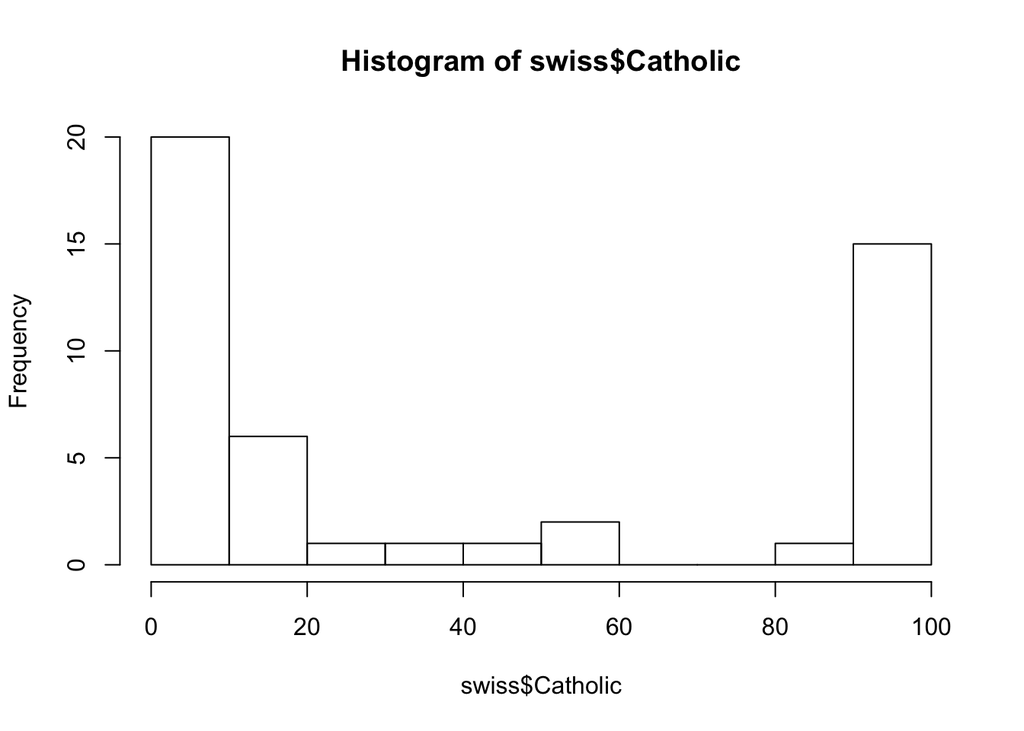

```r
hist(swiss$Catholic)
```

Notice that it’s very bimodal. That’s because most provinces are either majority Catholic or majority Protestant.

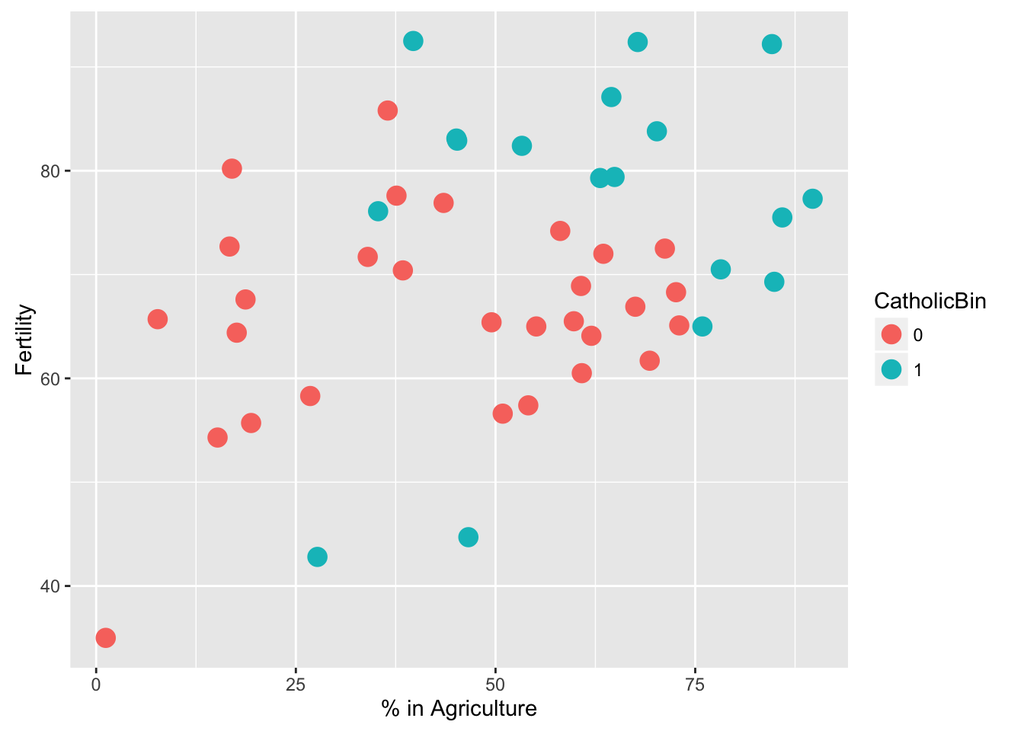

```r
#create binary catholic variable
#library(dplyr)
swiss2 = mutate(swiss, CatholicBin = 1 * (Catholic>50))
swiss2$CatholicBin <- as.factor(swiss2$CatholicBin)
#plot
g<-ggplot(swiss2, aes(x=Agriculture, y=Fertility, color=CatholicBin))
g<-g+geom_point(size=4)
g<-g+xlab("% in Agriculture") + ylab("Fertility")
g
```

Now, trying different models. First, create a model that doesn’t have religion at all - just Fertility and Agriculture. Ignores the color of the dots.

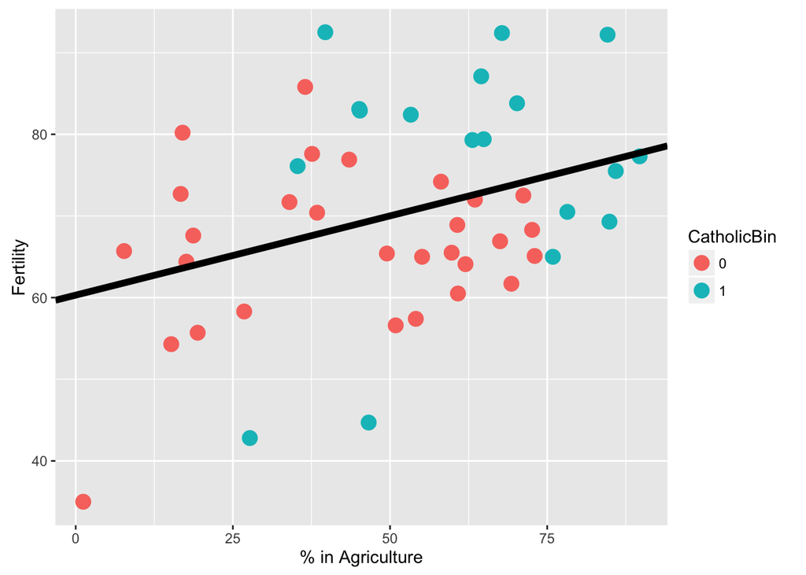

```r
fit1 <- lm(Fertility ~ Agriculture, swiss2)
g1 <-g
g1 <-g1 + geom_abline(intercept = coef(fit1)[1], slope=coef(fit1)[2], size=2)
g1
```

```r
summary(fit1)$coef
```

```
##               Estimate Std. Error   t value     Pr(>|t|)
## (Intercept) 60.3043752 4.25125562 14.185074 3.216304e-18
## Agriculture  0.1942017 0.07671176  2.531577 1.491720e-02
```

Next, fit parallel models.

```r
fit2 <- lm(Fertility ~ Agriculture + CatholicBin, swiss2)
summary(fit2)$coef
```

```
##                Estimate Std. Error   t value     Pr(>|t|)
## (Intercept)  60.8322366  4.1058630 14.815944 1.032493e-18
## Agriculture   0.1241776  0.0810977  1.531210 1.328763e-01
## CatholicBin1  7.8843292  3.7483622  2.103406 4.118221e-02
```

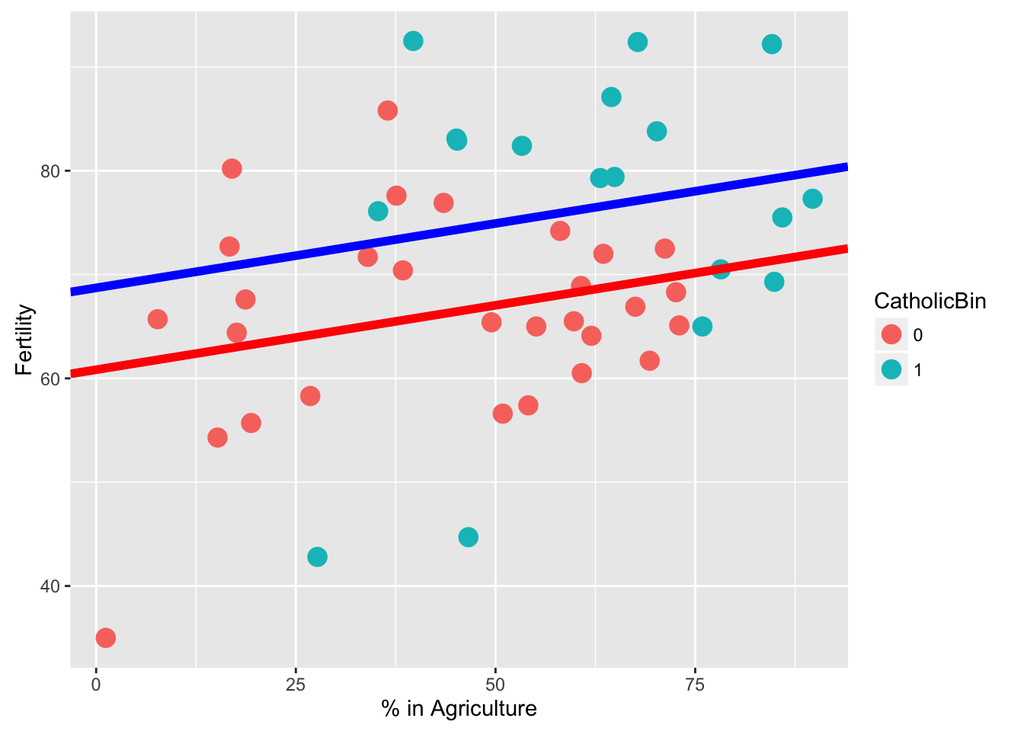

```r
#note: if no factor fit2 <- lm(Fertility ~ Agriculture + factor(CatholicBin), swiss2)
g1 <-g
g1 <-g1 + geom_abline(intercept = coef(fit2)[1], slope=coef(fit2)[2], size=2, color="red")
g1 <-g1 + geom_abline(intercept = coef(fit2)[1] + coef(fit2)[3], slope=coef(fit2)[2], size=2, color="blue")
g1
```

Two fitted lines: different intercepts and the same slope

Now, different slopes depending on the percent of the province that is Catholic.

```r
fit3 <- lm(Fertility ~ Agriculture * CatholicBin, swiss2)
summary(fit3)$coef
```

```
##                             Estimate  Std. Error    t value     Pr(>|t|)
## (Intercept)              62.04993019  4.78915566 12.9563402 1.919379e-16
## Agriculture               0.09611572  0.09881204  0.9727127 3.361364e-01
## CatholicBin1              2.85770359 10.62644275  0.2689238 7.892745e-01
## Agriculture:CatholicBin1  0.08913512  0.17610660  0.5061430 6.153416e-01
```

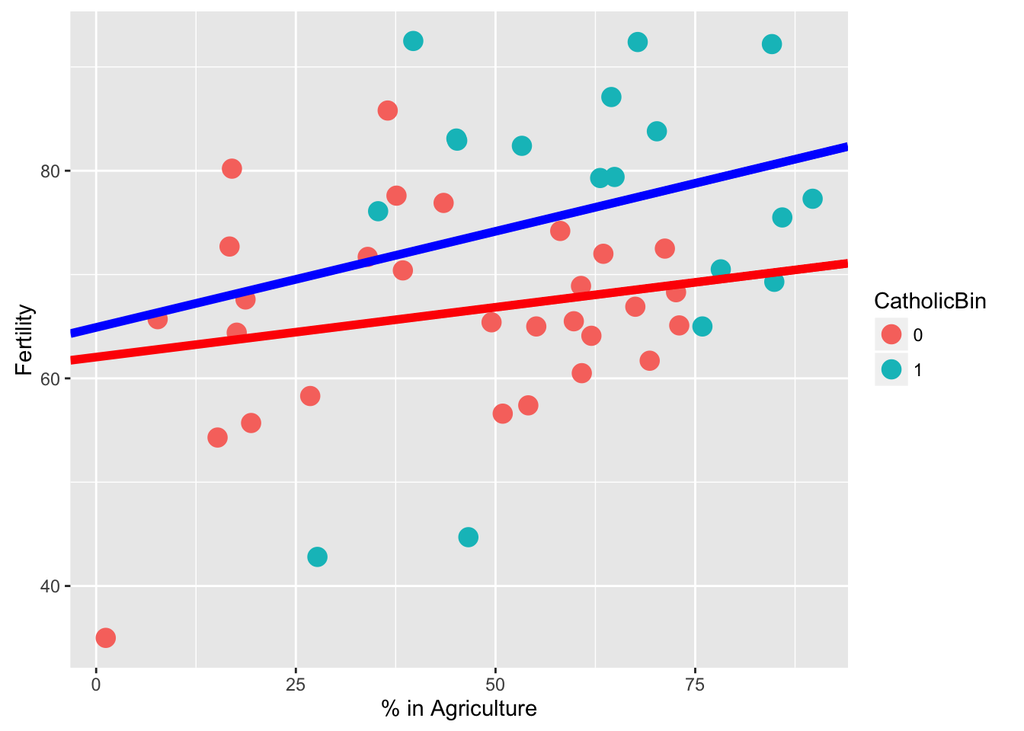

```r
#note: if no factor fit2 <- lm(Fertility ~ Agriculture + factor(CatholicBin), swiss2)
g1 <-g
g1 <-g1 + geom_abline(intercept = coef(fit3)[1], slope=coef(fit3)[2], size=2, color="red")
g1 <-g1 + geom_abline(intercept = coef(fit3)[1] + coef(fit3)[3], slope=coef(fit3)[2]+coef(fit3)[4] , size=2, color="blue")
g1
```

Adding an interaction term changed slopes of Catholic vs Protestant lines.